# Social_Media_Raj_Motwani_project

2024-26-04

```r
library(MASS)
library(ggplot2)
library(memisc)
library(ROCR)
library(dplyr)
library(klaR)
library(memisc)
library(ggplot2)
library(corrplot)
library(factoextra)
library(psych)
library(NbClust)
library(caTools)
library(magrittr)
library(pROC)
library(caret)


data <- read.csv("/Users/raj/downloads/Midterm_new.csv", row.names=1)
str(data)
```

```
## 'data.frame':    21 obs. of  11 variables:
##  $ Instagram_Usage           : num  3.5 7.44 3.46 5.23 0 2.2 5.22 7 8.39 12.1 ...
##  $ LinkedIn_Usage            : num  4 5.12 7 5.19 12.35 ...
##  $ Snapchat_Usage            : num  1 3.41 12.32 1.18 0 ...
##  $ Twitter_Usage             : num  5 12 0 0 12.4 0 0 0 0 0 ...
##  $ Whatsapp_Usage            : num  1 4.11 9.5 5.18 3 12 6 10 6.09 1 ...
##  $ Youtube_Usage             : num  2.5 4.15 1.51 2 3.3 7 3 2 4 3 ...
##  $ OTT                       : num  14.5 12 2 2 2 3 0 3 3 0 ...
##  $ Reddit                    : num  2.5 12 0 0 1 0 0 0 0 0 ...
##  $ Trouble_falling_asleep    : int  0 1 0 0 1 0 0 1 0 0 ...
##  $ Mood.Productivity         : int  1 1 1 1 1 1 1 1 1 0 ...
##  $ Tired_waking_up_in_morning: int  0 0 0 0 1 0 1 1 0 0 ...
```

```r
str(data)
```

```
## 'data.frame':    21 obs. of  11 variables:
##  $ Instagram_Usage           : num  3.5 7.44 3.46 5.23 0 2.2 5.22 7 8.39 12.1 ...
##  $ LinkedIn_Usage            : num  4 5.12 7 5.19 12.35 ...
##  $ Snapchat_Usage            : num  1 3.41 12.32 1.18 0 ...
##  $ Twitter_Usage             : num  5 12 0 0 12.4 0 0 0 0 0 ...
##  $ Whatsapp_Usage            : num  1 4.11 9.5 5.18 3 12 6 10 6.09 1 ...
##  $ Youtube_Usage             : num  2.5 4.15 1.51 2 3.3 7 3 2 4 3 ...
##  $ OTT                       : num  14.5 12 2 2 2 3 0 3 3 0 ...
##  $ Reddit                    : num  2.5 12 0 0 1 0 0 0 0 0 ...
##  $ Trouble_falling_asleep    : int  0 1 0 0 1 0 0 1 0 0 ...
##  $ Mood.Productivity         : int  1 1 1 1 1 1 1 1 1 0 ...
##  $ Tired_waking_up_in_morning: int  0 0 0 0 1 0 1 1 0 0 ...
```

```r
summary(data)
```

```
##  Instagram_Usage  LinkedIn_Usage   Snapchat_Usage   Twitter_Usage
##  Min.   : 0.000   Min.   : 1.520   Min.   : 0.000   Min.   : 0.000
##  1st Qu.: 3.500   1st Qu.: 3.450   1st Qu.: 0.000   1st Qu.: 0.000
##  Median : 5.300   Median : 4.000   Median : 1.250   Median : 0.000
##  Mean   : 5.779   Mean   : 5.784   Mean   : 4.046   Mean   : 2.253
##  3rd Qu.: 7.000   3rd Qu.: 7.000   3rd Qu.: 7.190   3rd Qu.: 2.250
##  Max.   :12.200   Max.   :12.480   Max.   :12.320   Max.   :12.400
##  Whatsapp_Usage   Youtube_Usage        OTT             Reddit
##  Min.   : 1.000   Min.   : 0.00   Min.   : 0.000   Min.   : 0.000
##  1st Qu.: 3.210   1st Qu.: 2.00   1st Qu.: 1.000   1st Qu.: 0.000
##  Median : 5.000   Median : 3.00   Median : 2.000   Median : 0.000
##  Mean   : 5.172   Mean   : 3.46   Mean   : 3.455   Mean   : 1.658
##  3rd Qu.: 6.570   3rd Qu.: 4.15   3rd Qu.: 3.000   3rd Qu.: 0.010
##  Max.   :12.000   Max.   :12.48   Max.   :14.500   Max.   :12.300
##  Trouble_falling_asleep Mood.Productivity Tired_waking_up_in_morning
##  Min.   :0.0000         Min.   :0.0000    Min.   :0.0000
##  1st Qu.:0.0000         1st Qu.:1.0000    1st Qu.:0.0000
##  Median :0.0000         Median :1.0000    Median :0.0000
##  Mean   :0.3333         Mean   :0.9524    Mean   :0.3333
##  3rd Qu.:1.0000         3rd Qu.:1.0000    3rd Qu.:1.0000
##  Max.   :1.0000         Max.   :1.0000    Max.   :1.0000
```

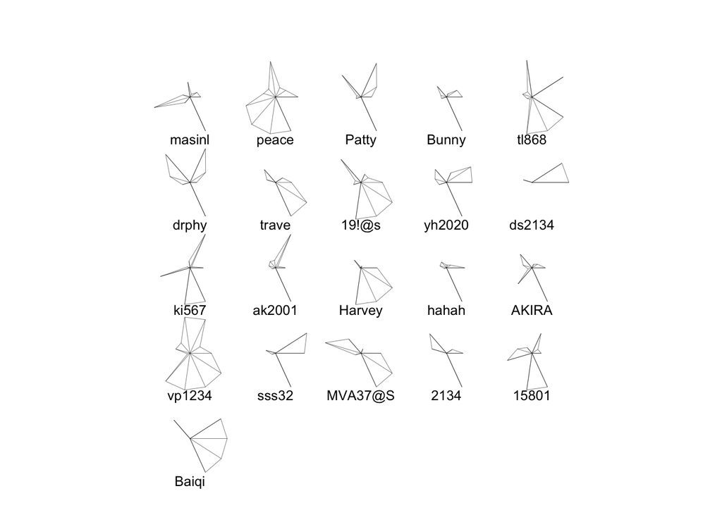

```r
stars(data)
```

Data Dictionary : Dataset ID: A unique identifier assigned to each student’s data entry. Instagram Usage: Duration of Instagram app usage. LinkedIn Usage: Duration of LinkedIn app usage. Snapchat Usage: Duration of Snapchat app usage. Twitter Usage: Duration of Twitter app usage. WhatsApp Usage: Duration of WhatsApp app usage. YouTube Usage: Duration of YouTube app usage. OTT Usage: Duration of Over-the-Top media services usage. Reddit Usage: Duration of Reddit app usage. Trouble Falling Asleep: Indicates whether the student reported difficulty falling asleep (0: No, 1: Yes). Mood Productivity: Subjective measure of the student’s mood and productivity level (0: Bad, 1: Good). Tiredness upon Waking Up in the Morning: Indicates the level of tiredness reported by the student upon waking up in the morning (0: Low, 1: High).

```r
cor_max <- cor(data[,1:11])
cor_max
```

```
##                            Instagram_Usage LinkedIn_Usage Snapchat_Usage
## Instagram_Usage                 1.00000000    0.418393819    -0.36795469
## LinkedIn_Usage                  0.41839382    1.000000000    -0.24766218
## Snapchat_Usage                 -0.36795469   -0.247662176     1.00000000
## Twitter_Usage                  -0.21923123    0.107169218     0.14412220
## Whatsapp_Usage                 -0.07161130   -0.046037532     0.18661870
## Youtube_Usage                  -0.10932223   -0.172289710     0.04975799
## OTT                            -0.26512565   -0.263791493     0.22119987
## Reddit                          0.05917577   -0.110041278     0.16176734
## Trouble_falling_asleep         -0.21668097   -0.187526982     0.21523900
## Mood.Productivity              -0.47748564   -0.376671078     0.18542625
## Tired_waking_up_in_morning      0.09383821    0.006570288    -0.22634945
##                            Twitter_Usage Whatsapp_Usage Youtube_Usage
## Instagram_Usage              -0.21923123    -0.07161130  -0.109322225
## LinkedIn_Usage                0.10716922    -0.04603753  -0.172289710
## Snapchat_Usage                0.14412220     0.18661870   0.049757992
## Twitter_Usage                 1.00000000    -0.28572123   0.046000253
## Whatsapp_Usage               -0.28572123     1.00000000   0.216695065
## Youtube_Usage                 0.04600025     0.21669506   1.000000000
## OTT                           0.31248404    -0.37660937  -0.003838841
## Reddit                        0.72184042    -0.08081563   0.107784743
## Trouble_falling_asleep        0.54976868    -0.19204135  -0.122055432
## Mood.Productivity             0.11899514     0.30233285   0.039705963
## Tired_waking_up_in_morning    0.20974248     0.21648298   0.081673262
##                                     OTT      Reddit Trouble_falling_asleep
## Instagram_Usage            -0.265125647  0.05917577             -0.2166810
## LinkedIn_Usage             -0.263791493 -0.11004128             -0.1875270
## Snapchat_Usage              0.221199865  0.16176734              0.2152390
## Twitter_Usage               0.312484039  0.72184042              0.5497687
## Whatsapp_Usage             -0.376609369 -0.08081563             -0.1920414
## Youtube_Usage              -0.003838841  0.10778474             -0.1220554
## OTT                         1.000000000  0.24831031              0.3778199
## Reddit                      0.248310312  1.00000000              0.3701470
## Trouble_falling_asleep      0.377819900  0.37014697              1.0000000
## Mood.Productivity           0.176971554  0.09908893              0.1581139
## Tired_waking_up_in_morning -0.356221375  0.04608834              0.3571429
##                            Mood.Productivity Tired_waking_up_in_morning
## Instagram_Usage                  -0.47748564                0.093838214
## LinkedIn_Usage                   -0.37667108                0.006570288
## Snapchat_Usage                    0.18542625               -0.226349450
## Twitter_Usage                     0.11899514                0.209742477
## Whatsapp_Usage                    0.30233285                0.216482982
## Youtube_Usage                     0.03970596                0.081673262
## OTT                               0.17697155               -0.356221375
## Reddit                            0.09908893                0.046088339
## Trouble_falling_asleep            0.15811388                0.357142857
## Mood.Productivity                 1.00000000                0.158113883
## Tired_waking_up_in_morning        0.15811388                1.000000000
```

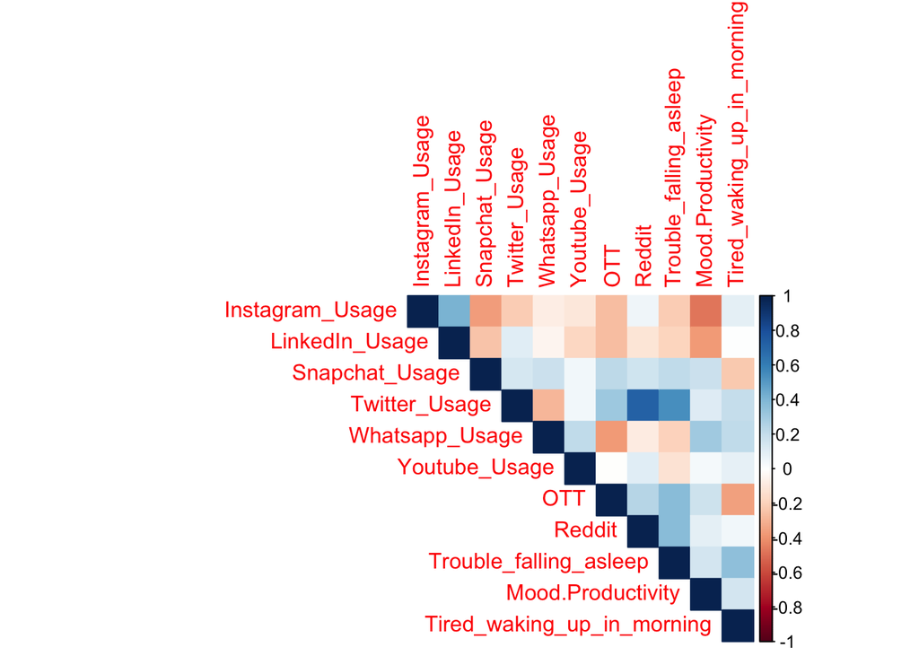

```r
corrplot(cor(data), type = "upper", method = "color")
```

QUESTIONS and HYPOTHESIS Questions : 1. Can we determine if students experience tiredness upon waking up in the morning due to social media usage, using the provided information? 2. Can we predict whether students experience tiredness upon waking up in the morning due to social media usage, using the provided data?

Hypothesis : We hypothesize that it is possible to utilize the duration of social media app usage by students to predict if they are affected by tiredness upon waking up in the morning.

The correlation matrix shows us a correlation between the columns in both cases. So, Principal Component Analysis (PCA) can help in reducing the number of columns used for analysis.

```r
# PCA

social_pca <- prcomp(data[,1:10],scale=TRUE)
social_pca
```

```
## Standard deviations (1, .., p=10):
##  [1] 1.6763580 1.4065023 1.1157669 0.9892280 0.9072510 0.8352641 0.7541027
##  [8] 0.7092987 0.5510073 0.3031702
##
## Rotation (n x k) = (10 x 10):
##                               PC1        PC2         PC3         PC4
## Instagram_Usage         0.3417734  0.3653165 -0.20766533 -0.03484560
## LinkedIn_Usage          0.2759944  0.3696592 -0.21155730  0.33825532
## Snapchat_Usage         -0.2894231 -0.2408067 -0.05039719  0.22668428
## Twitter_Usage          -0.4214083  0.3502277 -0.30019540  0.10302029
## Whatsapp_Usage          0.1030771 -0.4672780 -0.46861905  0.32775040
## Youtube_Usage          -0.0519227 -0.2156383 -0.48818227 -0.71544000
## OTT                    -0.3840995  0.1128398  0.35791020 -0.30060858
## Reddit                 -0.3608385  0.2760030 -0.47908817 -0.01352934
## Trouble_falling_asleep -0.4179812  0.1945396  0.06219957  0.22090182
## Mood.Productivity      -0.2826684 -0.3970439 -0.00646088  0.25248620
##                                PC5         PC6         PC7         PC8
## Instagram_Usage         0.02989600 -0.57511241  0.20783053 -0.29139037
## LinkedIn_Usage          0.10556558  0.58633474  0.27017845 -0.30370378
## Snapchat_Usage          0.81409761 -0.04468892  0.13981495  0.10302440
## Twitter_Usage          -0.10376513  0.31028230 -0.02968772  0.18363074
## Whatsapp_Usage          0.01192490 -0.14272151  0.03196236 -0.34697869
## Youtube_Usage           0.05928273  0.25413726 -0.12348017 -0.24045757
## OTT                     0.09543733 -0.01769580  0.54234802 -0.45728947
## Reddit                 -0.07667928 -0.34996451  0.20930368  0.30890380
## Trouble_falling_asleep -0.02340517 -0.13552687 -0.61690455 -0.53628217
## Mood.Productivity      -0.54336688  0.03277308  0.35859577 -0.09040765
##                                PC9        PC10
## Instagram_Usage         0.38580711 -0.31112486
## LinkedIn_Usage          0.07154978  0.32050233
## Snapchat_Usage          0.32976046 -0.02577787
## Twitter_Usage          -0.03018234 -0.67562584
## Whatsapp_Usage         -0.51633396 -0.18834545
## Youtube_Usage           0.23485248  0.06561066
## OTT                    -0.32340698 -0.06325322
## Reddit                 -0.18234838  0.51290742
## Trouble_falling_asleep  0.11585708  0.18512618
## Mood.Productivity       0.51318442  0.04710979
```

```r
summary(social_pca)
```

```
## Importance of components:
##                          PC1    PC2    PC3     PC4     PC5     PC6     PC7
## Standard deviation     1.676 1.4065 1.1158 0.98923 0.90725 0.83526 0.75410
## Proportion of Variance 0.281 0.1978 0.1245 0.09786 0.08231 0.06977 0.05687
## Cumulative Proportion  0.281 0.4788 0.6033 0.70119 0.78350 0.85327 0.91014
##                            PC8     PC9    PC10
## Standard deviation     0.70930 0.55101 0.30317
## Proportion of Variance 0.05031 0.03036 0.00919
## Cumulative Proportion  0.96045 0.99081 1.00000
```

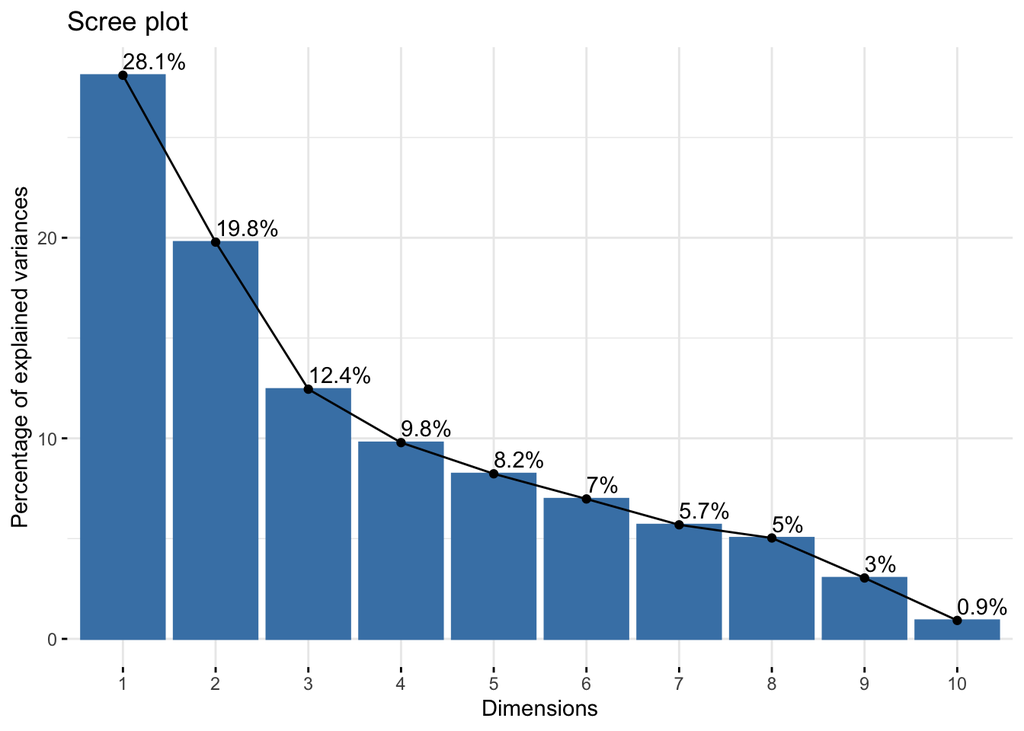

```r
fviz_eig(social_pca, addlabels = TRUE)
```

The scree plot indicates that the total variance explained by the first 2 principal components is less than 70%. Therefore, using PCA to reduce the number of columns may not be suitable. Next, we’ll explore Exploratory Factor Analysis (EFA) for this dataset.

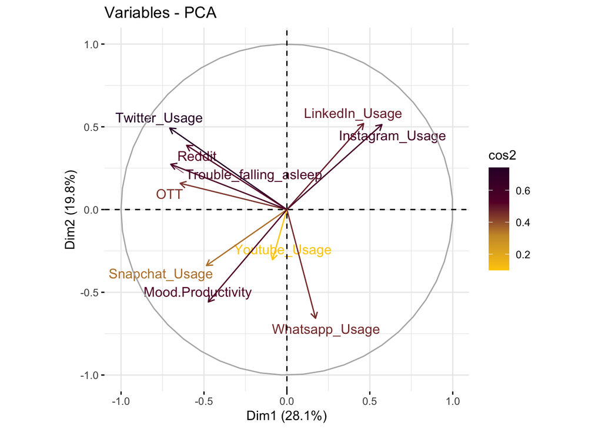

```r
fviz_pca_var(social_pca,col.var = "cos2",
             gradient.cols = c("#FFCC00", "#CC9933", "#660033", "#330033"),
             repel = TRUE)
```

#### FACTOR ANALYSIS :

```r
fit.pc <- principal(data[,1:8], nfactors=4, rotate="varimax")
fit.pc
```

```
## Principal Components Analysis
## Call: principal(r = data[, 1:8], nfactors = 4, rotate = "varimax")
## Standardized loadings (pattern matrix) based upon correlation matrix
##                   RC2   RC1   RC3   RC4   h2   u2 com
## Instagram_Usage -0.80  0.00  0.08 -0.08 0.65 0.35 1.0
## LinkedIn_Usage  -0.64  0.16  0.22 -0.43 0.68 0.32 2.2
## Snapchat_Usage   0.75  0.25  0.28 -0.19 0.75 0.25 1.7
## Twitter_Usage    0.07  0.90 -0.21 -0.05 0.87 0.13 1.1
## Whatsapp_Usage   0.18 -0.11  0.86  0.18 0.82 0.18 1.2
## Youtube_Usage    0.03  0.12  0.17  0.90 0.85 0.15 1.1
## OTT              0.42  0.25 -0.68  0.03 0.69 0.31 2.0
## Reddit           0.02  0.90 -0.06  0.14 0.84 0.16 1.1
##
##                        RC2  RC1  RC3  RC4
## SS loadings           1.82 1.80 1.41 1.10
## Proportion Var        0.23 0.23 0.18 0.14
## Cumulative Var        0.23 0.45 0.63 0.77
## Proportion Explained  0.30 0.29 0.23 0.18
## Cumulative Proportion 0.30 0.59 0.82 1.00
##
## Mean item complexity =  1.4
## Test of the hypothesis that 4 components are sufficient.
##
## The root mean square of the residuals (RMSR) is  0.1
##  with the empirical chi square  12.31  with prob <  0.0021
##
## Fit based upon off diagonal values = 0.83
```

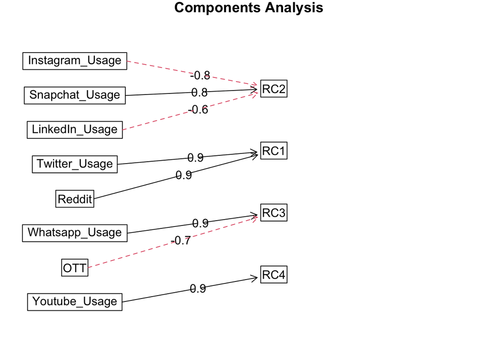

```r
fa.diagram(fit.pc)
```

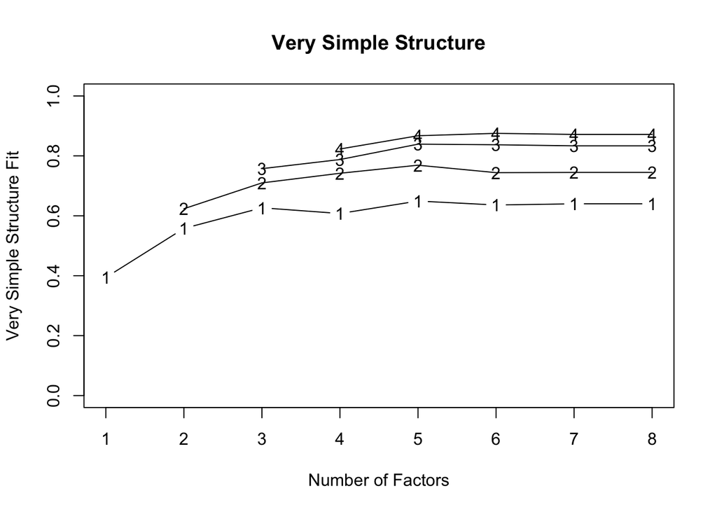

```
##
## Very Simple Structure
## Call: vss(x = data[, 1:8])
## Although the VSS complexity 1 shows  5  factors, it is probably more reasonable to think about  3  factors
## VSS complexity 2 achieves a maximimum of 0.77  with  5  factors
##
## The Velicer MAP achieves a minimum of 0.09  with  1  factors
## BIC achieves a minimum of  -36.44  with  1  factors
## Sample Size adjusted BIC achieves a minimum of  0.85  with  4  factors
##
## Statistics by number of factors
##   vss1 vss2   map dof   chisq prob sqresid  fit RMSEA   BIC SABIC complex
## 1 0.39 0.00 0.085  20 2.4e+01 0.22     7.0 0.39 0.091 -36.4 25.30     1.0
## 2 0.56 0.62 0.105  13 1.4e+01 0.38     4.3 0.62 0.029 -25.7 14.43     1.2
## 3 0.63 0.71 0.129   7 8.5e+00 0.29     2.8 0.76 0.087 -12.9  8.75     1.4
## 4 0.61 0.74 0.207   2 7.7e-01 0.68     2.0 0.82 0.000  -5.3  0.85     1.8
## 5 0.65 0.77 0.326  -2 1.9e-02   NA     1.4 0.88    NA    NA    NA     1.7
## 6 0.64 0.74 0.472  -5 3.2e-11   NA     1.3 0.89    NA    NA    NA     1.5
## 7 0.64 0.74 1.000  -7 0.0e+00   NA     1.3 0.89    NA    NA    NA     1.5
## 8 0.64 0.74    NA  -8 0.0e+00   NA     1.3 0.89    NA    NA    NA     1.5
##    eChisq    SRMR eCRMS  eBIC
## 1 3.2e+01 1.6e-01 0.195 -29.1
## 2 1.1e+01 9.8e-02 0.143 -28.4
## 3 3.3e+00 5.3e-02 0.105 -18.1
## 4 5.7e-01 2.2e-02 0.082  -5.5
## 5 4.0e-03 1.8e-03    NA    NA
## 6 3.9e-12 5.8e-08    NA    NA
## 7 7.4e-16 7.9e-10    NA    NA
## 8 7.4e-16 7.9e-10    NA    NA
```

```r
vss(data[,1:8])
```

RC1: Content Engagement: Measures user activity and interaction across content sharing platforms such as Twitter and Reddit.

RC3: Communication and Entertainment: Represents usage patterns emphasizing communication and entertainment through platforms such as Whatsapp and OTT services.

CLUSTERING:

```r
efa_data <- as.data.frame(fit.pc$scores)
efa_data
```

```
##                 RC2         RC1        RC3         RC4
## masinl   0.50199577  0.13819644 -2.2994808  0.05231959
## peace   -0.21276881  2.54984773 -0.9485184  0.53941315
## Patty    1.25188124 -0.20662132  1.5176849 -1.26457545
## Bunny   -0.09183227 -0.65684816 -0.1250449 -0.24089820
## tl868   -0.24529719  1.12152645 -0.2788583 -0.67514130
## drphy    1.34871513 -0.06310007  1.9952909  0.50674321
## trave   -0.19370853 -0.72149730  0.1217391  0.26337890
## 19!@s    0.15406552 -0.54313701  0.7984383 -0.14138070
## yh2020  -0.74409963 -0.20782042  0.4383534 -0.16343639
## ds2134  -2.07459232 -0.24265930 -0.3540690 -0.50451402
## ki567    1.59809222 -0.29578223 -1.4962368 -1.04345331
## ak2001   1.33991603 -0.24096753  0.1100830 -0.71648736
## Harvey   0.09911595 -0.91264978 -0.4678755 -0.34909645
## hahah   -0.18085176 -0.66483704 -0.5288647  0.02336224
## AKIRA    0.02923532  0.23828979  0.2142207  0.46135378
## vp1234   0.21535039  2.87270180  0.9412799  0.14250026
## sss32   -1.67299124 -0.26285031 -0.4531410 -0.46082853
## MVA37@S -0.31578810 -0.52814396  0.1434725  3.42102127
## 2134    -0.16587275 -0.65019298  0.6438035  1.01049566
## 15801    1.05060721 -0.53983622 -1.0212163  0.49180220
## Baiqi   -1.69117217 -0.18361857  1.0489394 -1.35257856
```

```r
matstd_sm <- scale(efa_data)



res.hc <- matstd_sm %>% scale() %>% dist(method = "euclidean") %>%
  hclust(method = "ward.D2")

res.nbclust <- matstd_sm %>% scale() %>% NbClust(distance = "euclidean", min.nc = 3, max.nc = 13, method = "complete", index ="all")
```

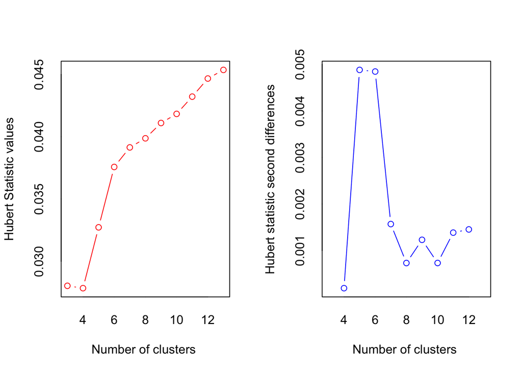

```
## *** : The Hubert index is a graphical method of determining the number of clusters.
##                 In the plot of Hubert index, we seek a significant knee that corresponds to a
##                 significant increase of the value of the measure i.e the significant peak in Hubert
##                 index second differences plot.
##
```

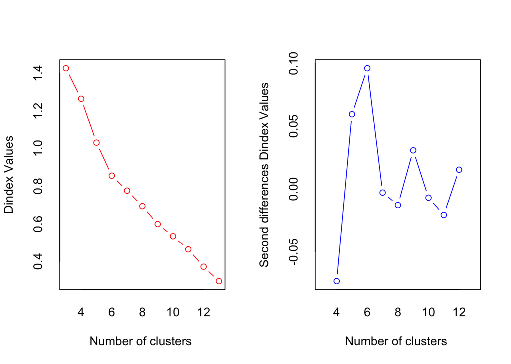

```
## *** : The D index is a graphical method of determining the number of clusters.
##                 In the plot of D index, we seek a significant knee (the significant peak in Dindex
##                 second differences plot) that corresponds to a significant increase of the value of
##                 the measure.
##
## * Among all indices:
## * 4 proposed 3 as the best number of clusters
## * 2 proposed 4 as the best number of clusters
## * 6 proposed 5 as the best number of clusters
## * 3 proposed 6 as the best number of clusters
## * 1 proposed 7 as the best number of clusters
## * 1 proposed 9 as the best number of clusters
## * 1 proposed 10 as the best number of clusters
## * 1 proposed 11 as the best number of clusters
## * 4 proposed 13 as the best number of clusters
##
##                    ***** Conclusion *****
##
## * According to the majority rule, the best number of clusters is  5
##
##
```

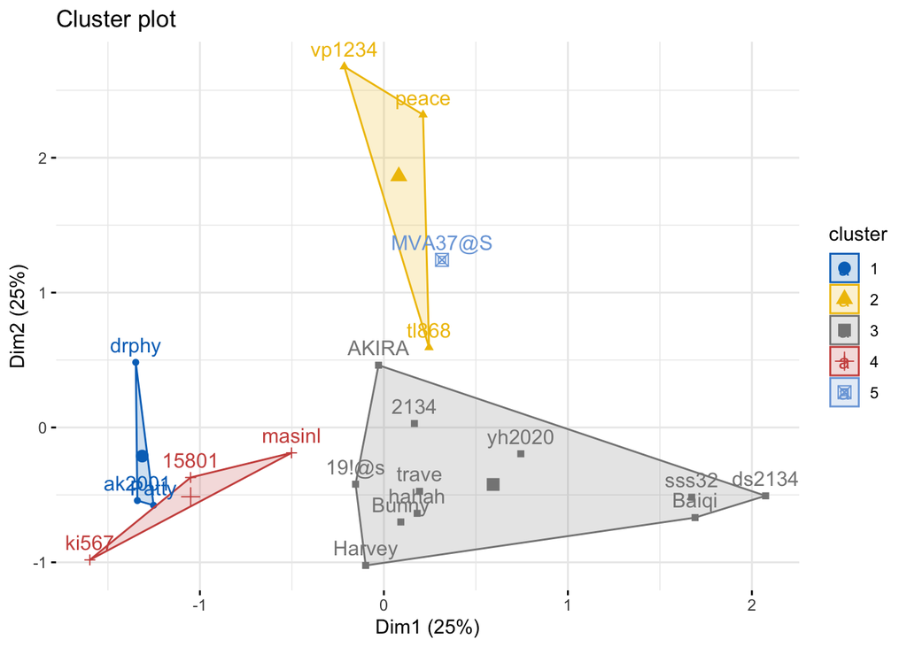

```r
km.res <- kmeans(matstd_sm, 5, nstart = 10)

fviz_cluster(km.res, data = matstd_sm,
             ellipse.type = "convex",
             palette = "jco",
             ggtheme = theme_minimal())
```

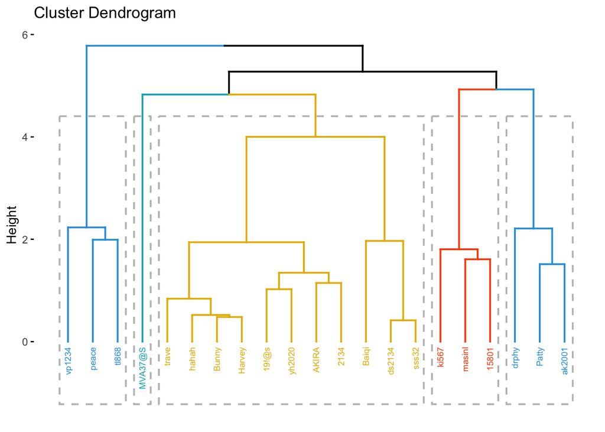

```r
dist.data <- dist(matstd_sm, method="euclidean")



fviz_dend(res.hc, k = 5, # Cut in four groups
          cex = 0.5, # label size
          k_colors = c("#2E9FDF", "#00AFBB", "#E7B800", "#FC4E07"),
          color_labels_by_k = TRUE, # color labels by groups
          rect = TRUE # Add rectangle around groups
)
```

```r
Clustered <- ifelse(km.res$cluster > 1.5, "NO Trouble waking up", "Trouble waking up")
Actual <- ifelse(data$Trouble_falling_asleep == 1, "Trouble waking up", "No trouble waking up ")
confusion_mat <- table(Clustered, Actual)
confusion_mat
```

```
##                       Actual
## Clustered              No trouble waking up  Trouble waking up
##   NO Trouble waking up                    11                 7
##   Trouble waking up                        3                 0
```

```r
accuracy <- sum(diag(confusion_mat)) / sum(confusion_mat)
precision <- confusion_mat[2, 2] / sum(confusion_mat[, 2])
recall <- confusion_mat[2, 2] / sum(confusion_mat[2, ])
cat("Accuracy:", round(accuracy, 3), "\n")
```

```
## Accuracy: 0.524
```

REGRESSION :

```r
wdbc <- read.csv("/Users/raj/downloads/Midterm_new.csv")
features <- c("Instagram", "LinkedIn", "Snapchat", "Twitter", "Whatsapp", "Youtube", "OTT", "Reddit", "Trouble_sleep", "Mood", "Tired_morning")
names(wdbc) <- c("ID", "Instagram", "LinkedIn", "Snapchat", "Twitter", "Whatsapp", "Youtube", "OTT", "Reddit", "Trouble_sleep", "Mood", "Tired_morning")
wdbc<- wdbc
wdbc.data <- as.matrix(wdbc[,c(2:9)])
row.names(wdbc.data) <- wdbc$ID
```

DATA SPLITTING :

```r
wdbc_raw <- cbind(wdbc.data, as.numeric(as.factor(wdbc$Trouble_sleep))-1)
colnames(wdbc_raw)[9] <- "Tired_waking_up_in_morning"
# Create train and test datasets
train_raw.df <- as.data.frame(wdbc_raw)
test_raw.df <- as.data.frame(wdbc_raw)
test_raw.df
```

```
##         Instagram LinkedIn Snapchat Twitter Whatsapp Youtube   OTT Reddit
## masinl       3.50     4.00     1.00    5.00     1.00    2.50 14.50   2.50
## peace        7.44     5.12     3.41   12.00     4.11    4.15 12.00  12.00
## Patty        3.46     7.00    12.32    0.00     9.50    1.51  2.00   0.00
## Bunny        5.23     5.19     1.18    0.00     5.18    2.00  2.00   0.00
## tl868        0.00    12.35     0.00   12.40     3.00    3.30  2.00   1.00
## drphy        2.20     7.00    12.28    0.00    12.00    7.00  3.00   0.00
## trave        5.22     4.00     0.00    0.00     6.00    3.00  0.00   0.00
## 19!@s        7.00     4.00     3.00    0.00    10.00    2.00  3.00   0.00
## yh2020       8.39    10.00     3.50    0.00     6.09    4.00  3.00   0.00
## ds2134      12.10    12.00     0.00    0.00     1.00    3.00  0.00   0.00
## ki567        4.35     2.08    12.25    2.25     1.00    1.00 12.00   0.00
## ak2001       3.20     2.30    12.20    2.50     3.40    2.30  1.30   0.00
## Harvey       5.30     1.52     0.62    0.00     4.02    0.54  0.51   0.01
## hahah        6.00     3.00     1.00    1.00     3.25    2.30  1.00   0.00
## AKIRA        4.39     3.45     1.25    0.00     6.30    3.08  1.55   7.00
## vp1234       7.00     5.00    12.25   12.16     5.00    5.00  1.00  12.30
## sss32        9.48    12.48     0.00    0.00     1.21    3.32  1.41   0.00
## MVA37@S      6.48     1.55     1.52    0.00     6.57   12.48  2.28   0.00
## 2134         5.40     3.55     0.00    0.00     8.55    5.09  0.00   0.00
## 15801        3.01     3.57     7.19    0.00     3.21    5.10 10.00   0.00
## Baiqi       12.20    12.31     0.00    0.00     8.23    0.00  0.00   0.00
##         Tired_waking_up_in_morning
## masinl                           0
## peace                            1
## Patty                            0
## Bunny                            0
## tl868                            1
## drphy                            0
## trave                            0
## 19!@s                            1
## yh2020                           0
## ds2134                           0
## ki567                            1
## ak2001                           0
## Harvey                           1
## hahah                            0
## AKIRA                            0
## vp1234                           1
## sss32                            0
## MVA37@S                          0
## 2134                             0
## 15801                            1
## Baiqi                            0
```

LOGISTIC REGRESSION :

Logistic regression is a statistical approach used to classify data into two categories. It estimates the likelihood that an observation belongs to one of two classes. It establishes the connection between a binary outcome and one or multiple independent variables.

```r
data <- read.csv("/Users/raj/downloads/Midterm_new.csv")
logistic_data <- glm(Tired_waking_up_in_morning ~ ., data = data, family = 'binomial')
summary(logistic_data)
```

```
##
## Call:
## glm(formula = Tired_waking_up_in_morning ~ ., family = "binomial",
##     data = data)
##
## Coefficients: (10 not defined because of singularities)
##                          Estimate Std. Error z value Pr(>|z|)
## (Intercept)            -2.557e+01  2.160e+05       0        1
## ID19!@s                 5.113e+01  3.055e+05       0        1
## ID2134                 -1.429e-15  3.055e+05       0        1
## IDak2001               -1.273e-14  3.055e+05       0        1
## IDAKIRA                 1.852e-14  3.055e+05       0        1
## IDBaiqi                 5.113e+01  3.055e+05       0        1
## IDBunny                -6.718e-14  3.055e+05       0        1
## IDdrphy                -6.844e-14  3.055e+05       0        1
## IDds2134               -5.892e-15  3.055e+05       0        1
## IDhahah                 4.289e-15  3.055e+05       0        1
## IDHarvey                5.113e+01  3.055e+05       0        1
## IDki567                -5.588e-14  3.055e+05       0        1
## IDmasinl                6.646e-14  3.055e+05       0        1
## IDMVA37@S               5.113e+01  3.055e+05       0        1
## IDPatty                -1.598e-14  3.055e+05       0        1
## IDpeace                 2.585e-14  3.055e+05       0        1
## IDsss32                 2.977e-14  3.055e+05       0        1
## IDtl868                 5.113e+01  3.055e+05       0        1
## IDtrave                 5.113e+01  3.055e+05       0        1
## IDvp1234                5.113e+01  3.055e+05       0        1
## IDyh2020                4.108e-15  3.055e+05       0        1
## Instagram_Usage                NA         NA      NA       NA
## LinkedIn_Usage                 NA         NA      NA       NA
## Snapchat_Usage                 NA         NA      NA       NA
## Twitter_Usage                  NA         NA      NA       NA
## Whatsapp_Usage                 NA         NA      NA       NA
## Youtube_Usage                  NA         NA      NA       NA
## OTT                            NA         NA      NA       NA
## Reddit                         NA         NA      NA       NA
## Trouble_falling_asleep         NA         NA      NA       NA
## Mood.Productivity              NA         NA      NA       NA
##
## (Dispersion parameter for binomial family taken to be 1)
##
##     Null deviance: 2.6734e+01  on 20  degrees of freedom
## Residual deviance: 3.3117e-10  on  0  degrees of freedom
## AIC: 42
##
## Number of Fisher Scoring iterations: 24
```

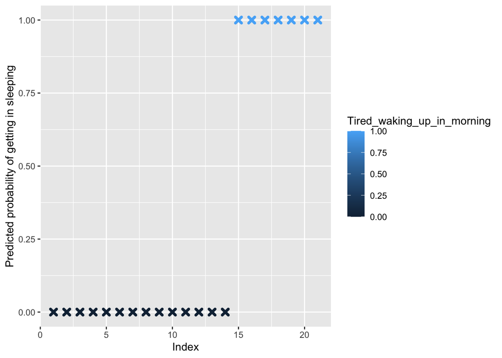

```r
predicted.data <- data.frame(probability.of.hd=logistic_data$fitted.values,Tired_waking_up_in_morning=data$Tired_waking_up_in_morning)
predicted.data <- predicted.data[order(predicted.data$probability.of.hd, decreasing=FALSE),]
predicted.data$rank <- 1:nrow(predicted.data)

ggplot(data=predicted.data, aes(x=rank, y=probability.of.hd)) +
  geom_point(aes(color=Tired_waking_up_in_morning), alpha=1, shape=4, stroke=2) +
  xlab("Index") +
  ylab("Predicted probability of getting in sleeping")
```

```r
probabilities_sm2 <- predict(logistic_data, new_data = test_raw.df, type = "response")
probabilities_sm2
```

```
##            1            2            3            4            5            6
## 7.884924e-12 7.884924e-12 7.884924e-12 7.884924e-12 1.000000e+00 7.884924e-12
##            7            8            9           10           11           12
## 1.000000e+00 1.000000e+00 7.884924e-12 7.884924e-12 7.884924e-12 7.884924e-12
##           13           14           15           16           17           18
## 1.000000e+00 7.884924e-12 7.884924e-12 1.000000e+00 7.884924e-12 1.000000e+00
##           19           20           21
## 7.884924e-12 7.884924e-12 1.000000e+00
```

```r
predicted_sm2 <- ifelse(probabilities_sm2 > 0.5, "Yes", "No")
predicted_sm2
```

```
##     1     2     3     4     5     6     7     8     9    10    11    12    13
##  "No"  "No"  "No"  "No" "Yes"  "No" "Yes" "Yes"  "No"  "No"  "No"  "No" "Yes"
##    14    15    16    17    18    19    20    21
##  "No"  "No" "Yes"  "No" "Yes"  "No"  "No" "Yes"
```

```r
actual_sm <- ifelse(test_raw.df$Tired_waking_up_in_morning == 1, "Yes", "No")

confusion_sm2 <- table(predicted_sm2, actual_sm)
confusion_sm2
```

```
##              actual_sm
## predicted_sm2 No Yes
##           No  11   3
##           Yes  3   4
```

```r
accuracy2 <- sum(diag(confusion_sm2)) / sum(confusion_sm2)
precision2 <- confusion_sm2[2, 2] / sum(confusion_sm2[, 2])
recall2 <- confusion_sm2[2, 2] / sum(confusion_sm2[2, ])
cat("Accuracy:", round(accuracy2, 3), "\n")
```

```
## Accuracy: 0.714
```

```r
cat("Precision:", round(precision2, 3), "\n")
```

```
## Precision: 0.571
```

```r
cat("Recall:", round(recall2, 3), "\n")
```

```
## Recall: 0.571
```

```r
probabilities <- predict(logistic_data, new_data = test_raw.df, type = "response")

roc_sm <- roc(test_raw.df$Tired_waking_up_in_morning, probabilities_sm2)
```

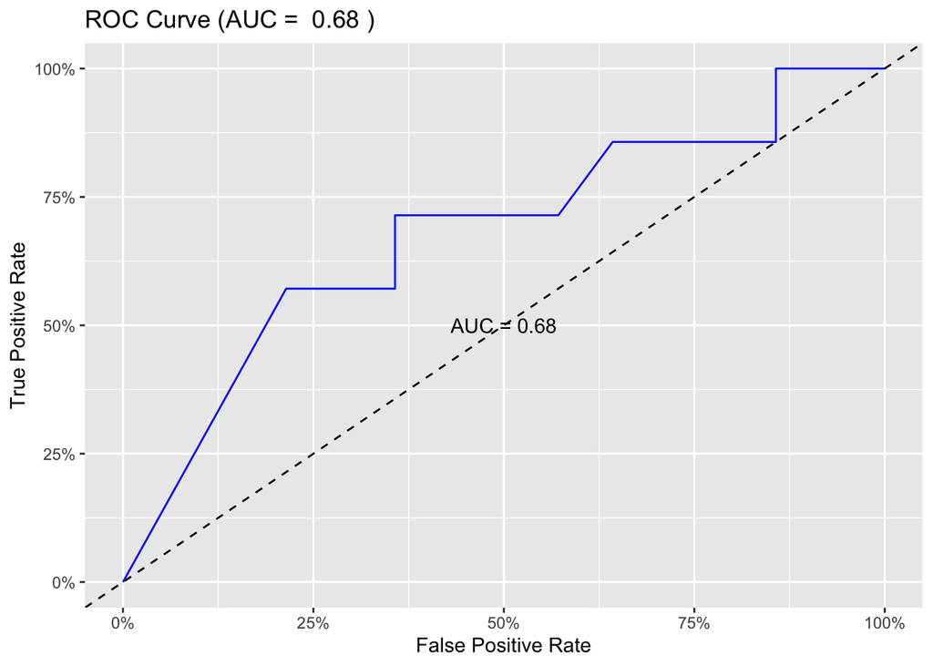

```r
auc_sm <- auc(roc_sm)

ggroc(roc_sm, color = "blue", legacy.axes = TRUE) +
  geom_abline(intercept = 0, slope = 1, linetype = "dashed") +
  scale_x_continuous(labels = scales::percent_format()) +
  scale_y_continuous(labels = scales::percent_format()) +
  labs(x = "False Positive Rate", y = "True Positive Rate",
       title = paste("ROC Curve (AUC = ", round(auc_sm, 2), ")")) +
  annotate("text", x = 0.5, y = 0.5, label = paste0("AUC = ", round(auc_sm, 2)))
```